# Week 9 Statistics Study Guide: Regression Inference, Diagnostics & Multiple Regression

Ken Black (Ch. 12.4–12.7 & Ch. 13) and Wilcox (Ch. 8.3)

Eric Schmidt

2026-11-25

# 1 Overview & Learning Objectives

The Week 9 readings complete **Simple Linear Regression** (Ken Black Sections 12.4–12.7 and 12.9), introduce **Multiple Regression Analysis** (Ken Black Chapter 13), and examine the properties, limitations, and diagnostic cautions of **Pearson’s Correlation** and the **Coefficient of Determination** (Wilcox Chapter 8, Section 8.3). By the end of this module, you should be able to:

1. Perform **residual analysis** to verify the LINE assumptions (Linearity, Independence, Normality, Equal Variance / Homoscedasticity) and compute the **standard error of the estimate ($s_e$)**.
2. Conduct **hypothesis tests** and construct **confidence intervals** for the population regression slope ($\beta_1$) and population correlation ($\rho$).
3. Distinguish between a **confidence interval for the conditional mean** $E(Y \mid x_0)$ and a **prediction interval for an individual observation** $Y_0$, and apply regression to **trend-line forecasting**.
4. Formulate and interpret a **Multiple Regression** model with $k$ predictor variables, including **Adjusted $R^2$**, the overall **$F$-test**, and individual predictor **$t$-tests**.
5. Incorporate **dummy (indicator) variables**, diagnose **multicollinearity** using Variance Inflation Factors ($VIF$), and apply stabilizing transformations (such as $\log_{10}$) when heteroscedasticity appears.
6. Critically evaluate Pearson’s $r$ and $r^2$ using Wilcox’s five data features (slope, residual magnitude, outliers, range restriction, and curvature) and understand why heteroscedasticity invalidates standard $t$-tests for $\rho = 0$.

# 2 Black Chapter 12 (Sections 12.4–12.9): Simple Linear Regression Inference, Diagnostics & Forecasting

## 2.1 Residual Analysis & Standard Error of the Estimate (Section 12.4)

A **residual** is the vertical distance between an observed value $y_i$ and its predicted value $\hat{y}_i$:

$$e_i = y_i - \hat{y}_i$$

- **Inputs:**
  - $y_i$: The $i$-th observed value of the dependent variable.
  - $\hat{y}_i = b_0 + b_1 x_i$: The $i$-th predicted (fitted) value from the estimated regression equation.

Summing the squared residuals produces the **Sum of Squares of Error ($SSE$)**, from which the **Standard Error of the Estimate ($s_e$)** measures the typical dispersion of observed data points around the regression line in the units of $Y$:

$$SSE = \sum_{i=1}^{n} e_i^2 =
\sum_{i=1}^{n} (y_i - \hat{y}_i)^2, \qquad s_e = \sqrt{\frac{SSE}{n -
2}}$$

- **Inputs:**
  - $e_i$: Residual for observation $i$.
  - $n$: Total number of paired observations $(x_i, y_i)$ ($df = n - 2$ because two parameters, $b_0$ and $b_1$, are estimated).

Under normally distributed errors centered at $0$, the Empirical Rule implies that roughly $95\%$ of residuals should fall within $0 \pm 2s_e$. Plotting residuals ($e_i$) against $x_i$ or $\hat{y}_i$ diagnoses violations of the **LINE** assumptions:

1. **Linearity:** Residuals should scatter randomly around the horizontal $0$ line with no curved pattern.
2. **Independence:** No systematic pattern across time/order (verified via time-sequence residual plots or the Durbin-Watson test).
3. **Normality:** Histogram or Normal Q-Q plot of residuals should align closely along the diagonal reference line.
4. **Equal Variance (Homoscedasticity):** The vertical spread of residuals should remain roughly constant across all values of $x_i$ (a “megaphone” or funnel shape indicates **heteroscedasticity**).

### 2.1.1 R Application: Airline Cost Data (Black Table 12.3, p. 429)

In the Chapter 12 R supplement, operating cost (`cost_1000`, in $\$1,000\text{s}$) is modeled as a linear function of the number of passengers (`no_of_pass`) across $n = 12$ flights. We fit the model, visualize the vertical residual segments, calculate $SSE$ and $s_e$, and inspect the four standard R diagnostic plots.

```r
no_of_pass <- c(61, 63, 67, 69, 70, 74, 76, 81, 86, 91, 95, 97)
cost_1000 <- c(4.28, 4.08, 4.42, 4.17, 4.48, 4.3, 4.82, 4.7, 5.11, 5.13, 5.64, 5.56)
airline_df <- data.frame(no_of_pass = no_of_pass, cost_1000 = cost_1000)

airline_model <- lm(cost_1000 ~ no_of_pass, data = airline_df)
airline_df$fitted_cost <- fitted(airline_model)
airline_df$resid_cost <- residuals(airline_model)

sse_airline <- sum(airline_df$resid_cost^2)
n_airline <- nrow(airline_df)
rse_airline <- sqrt(sse_airline / (n_airline - 2))

print(sprintf("Fitted Equation: cost_hat = %.4f + %.6f * no_of_pass",
              coef(airline_model)[1], coef(airline_model)[2]))
```

```
## [1] "Fitted Equation: cost_hat = 1.5698 + 0.040702 * no_of_pass"
```

```r
print(sprintf("SSE = %.6f | s_e (formula) = %.6f | summary()$sigma = %.6f",
              sse_airline, rse_airline, summary(airline_model)$sigma))
```

```
## [1] "SSE = 0.314060 | s_e (formula) = 0.177217 | summary()$sigma = 0.177217"
```

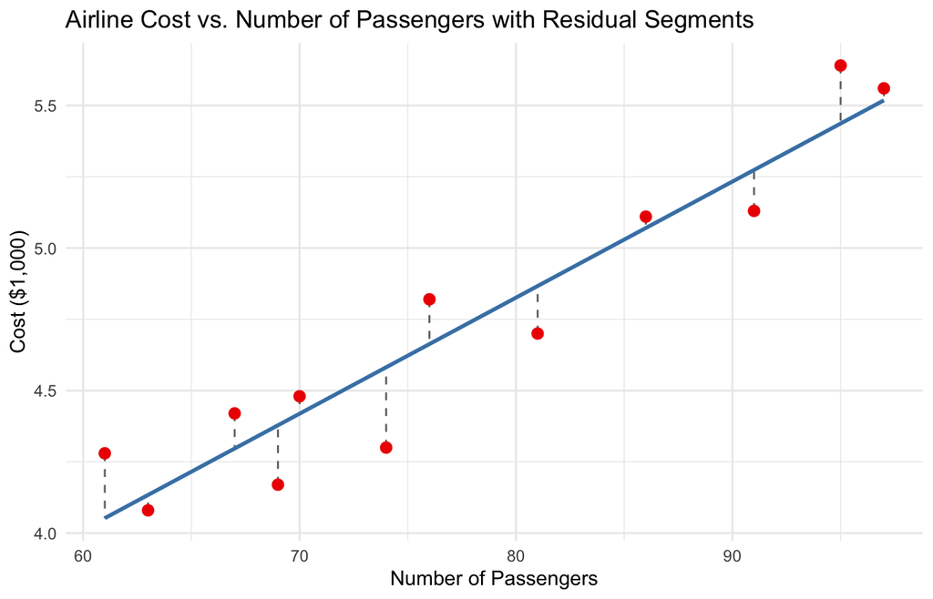

```r
ggplot(airline_df, aes(x = no_of_pass, y = cost_1000)) +
  geom_segment(aes(xend = no_of_pass, yend = fitted_cost), color = "gray45", linetype = "dashed") +
  geom_smooth(method = "lm", se = FALSE, color = "steelblue", linewidth = 1) +
  geom_point(color = "red2", size = 2.5) +
  labs(title = "Airline Cost vs. Number of Passengers with Residual Segments",
       x = "Number of Passengers",
       y = "Cost ($1,000)") +
  theme_minimal()
```

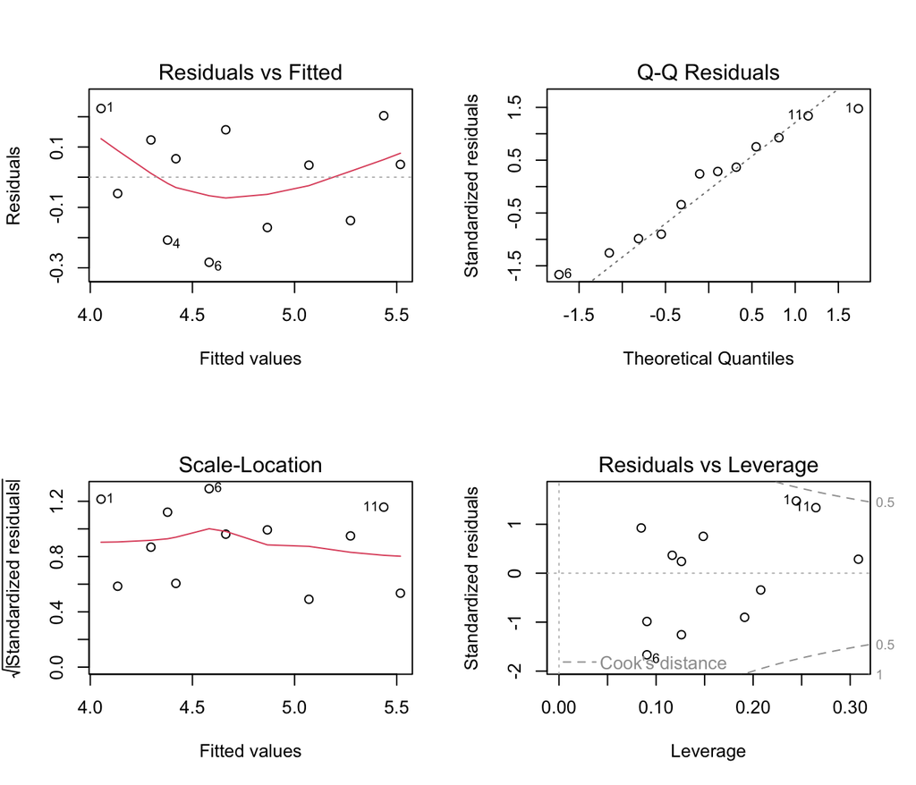

```r
par(mfrow = c(2, 2))
plot(airline_model)
```

## 2.2 Hypothesis Tests About the Slope ($\beta_1$) & Confidence Intervals (Section 12.5)

To test whether $X$ has a statistically significant linear effect on $Y$, we test whether the population slope $\beta_1$ differs from a hypothesized value $\beta_{1,0}$ (typically $\beta_{1,0} = 0$).

### 2.2.1 Standard Error of the Slope ($s_{b_1}$)

$$s_{b_1} = \frac{s_e}{\sqrt{SS_{xx}}} =
\frac{s_e}{\sqrt{\sum_{i=1}^{n} (x_i - \bar{x})^2}} =
\frac{s_e}{\sqrt{\sum_{i=1}^{n} x_i^2 - \frac{(\sum_{i=1}^{n}
x_i)^2}{n}}}$$

- **Inputs:**
  - $s_e$: Standard error of the estimate.
  - $SS_{xx} = \sum (x_i - \bar{x})^2$: Sum of squared deviations of the predictor $X$.
  - $n$: Sample size.

### 2.2.2 Testing the Population Slope ($H_0: \beta_1 = \beta_{1,0}$) & Confidence Interval

- **Test Statistic:**
  $$t =
  \frac{b_1 - \beta_{1,0}}{s_{b_1}}, \quad \text{with } df = n -
  2$$
- **Confidence Interval for $\beta_1$:**
  $$b_1 \pm t_{\alpha/2,\, n-2} \cdot
  s_{b_1}$$
- **Inputs:**
  - $b_1$: Sample regression slope.
  - $\beta_{1,0}$: Hypothesized population slope under $H_0$ (usually $0$).
  - $s_{b_1}$: Standard error of the sample slope.
  - $t_{\alpha/2,\, n-2}$: Two-tailed critical $t$-value at significance level $\alpha$ with $df = n - 2$.

```r
b1 <- coef(airline_model)[2]
ss_xx <- sum((no_of_pass - mean(no_of_pass))^2)
s_b1 <- rse_airline / sqrt(ss_xx)
t_slope <- (b1 - 0) / s_b1
p_slope <- 2 * pt(abs(t_slope), df = n_airline - 2, lower.tail = FALSE)
t_crit_95 <- qt(0.975, df = n_airline - 2)
ci_slope_manual <- c(b1 - t_crit_95 * s_b1, b1 + t_crit_95 * s_b1)

print(sprintf("SS_xx = %.2f | s_b1 = %.6f | t_obs = %.4f | p-value = %.6e",
              ss_xx, s_b1, t_slope, p_slope))
```

```
## [1] "SS_xx = 1689.00 | s_b1 = 0.004312 | t_obs = 9.4389 | p-value = 2.691644e-06"
```

```r
print(sprintf("Manual 95%% CI for beta_1: [%.6f, %.6f]",
              ci_slope_manual[1], ci_slope_manual[2]))
```

```
## [1] "Manual 95% CI for beta_1: [0.031094, 0.050310]"
```

```r
print(coef(summary(airline_model)))
```

```
##              Estimate  Std. Error  t value     Pr(>|t|)
## (Intercept) 1.5697928 0.338082961 4.643218 9.174811e-04
## no_of_pass  0.0407016 0.004312128 9.438865 2.691644e-06
```

```r
print(confint(airline_model, level = 0.95))
```

```
##                  2.5 %     97.5 %
## (Intercept) 0.81649700 2.32308856
## no_of_pass  0.03109358 0.05030962
```

Because $t = 9.439$ ($p = 2.69 \times 10^{-6} < 0.05$) and the $95\%$ confidence interval $[0.0311, 0.0503]$ excludes $0$, we reject $H_0: \beta_1 = 0$ and conclude that number of passengers is a statistically significant linear predictor of operating cost.

## 2.3 Estimation & Prediction Intervals (Section 12.6)

For a specific predictor value $x_0$, the point estimate is $\hat{y}_0 = b_0 + b_1 x_0$. However, the margin of error depends on whether we are estimating the **average** outcome across all units at $x_0$ or predicting a **single individual** outcome:

1. **Confidence Interval for the Conditional Mean $E(Y \mid x_0)$:**
   $$\hat{y}_0 \pm t_{\alpha/2,\, n-2} \, s_e
   \sqrt{\frac{1}{n} + \frac{(x_0 - \bar{x})^2}{SS_{xx}}}$$
2. **Prediction Interval for a Single Individual Value $Y_0$:**
   $$\hat{y}_0 \pm t_{\alpha/2,\, n-2} \, s_e \sqrt{1
   + \frac{1}{n} + \frac{(x_0 - \bar{x})^2}{SS_{xx}}}$$
- **Inputs:**
  - $\hat{y}_0 = b_0 + b_1 x_0$: Predicted response at $x_0$.
  - $t_{\alpha/2,\, n-2}$: Critical $t$-value for confidence level $1 - \alpha$ and $df = n - 2$.
  - $s_e$: Standard error of the estimate.
  - $n$: Number of sample observations.
  - $x_0$: Target predictor value; $\bar{x}$: Sample mean of $X$; $SS_{xx}$: Sum of squares of $X$.

*Key Insight:* The prediction interval is always **wider** than the confidence interval because of the additional $+1$ inside the square root (accounting for individual variation $\epsilon_i$ around the mean). Both intervals are narrowest at $x_0 = \bar{x}$ and widen as $x_0$ moves away from $\bar{x}$, making **extrapolation** beyond the observed range of $X$ risky.

### 2.3.1 R Application: Predicting Cost at 73 Passengers (Black pp. 453–454)

```r
x0 <- 73
y0_hat <- coef(airline_model)[1] + b1 * x0
leverage_term <- (1 / n_airline) + ((x0 - mean(no_of_pass))^2 / ss_xx)

ci_manual <- y0_hat + c(-1, 1) * t_crit_95 * rse_airline * sqrt(leverage_term)
pi_manual <- y0_hat + c(-1, 1) * t_crit_95 * rse_airline * sqrt(1 + leverage_term)

new_pass <- data.frame(no_of_pass = x0)
ci_r <- predict(airline_model, newdata = new_pass, interval = "confidence", level = 0.95)
pi_r <- predict(airline_model, newdata = new_pass, interval = "prediction", level = 0.95)

print(sprintf("Point Estimate at x0 = 73: %.6f", y0_hat))
```

```
## [1] "Point Estimate at x0 = 73: 4.541009"
```

```r
print(sprintf("Manual 95%% CI: [%.6f, %.6f] | predict(): [%.6f, %.6f]",
              ci_manual[1], ci_manual[2], ci_r[2], ci_r[3]))
```

```
## [1] "Manual 95% CI: [4.419097, 4.662922] | predict(): [4.419097, 4.662922]"
```

```r
print(sprintf("Manual 95%% PI: [%.6f, %.6f] | predict(): [%.6f, %.6f]",
              pi_manual[1], pi_manual[2], pi_r[2], pi_r[3]))
```

```
## [1] "Manual 95% PI: [4.127753, 4.954266] | predict(): [4.127753, 4.954266]"
```

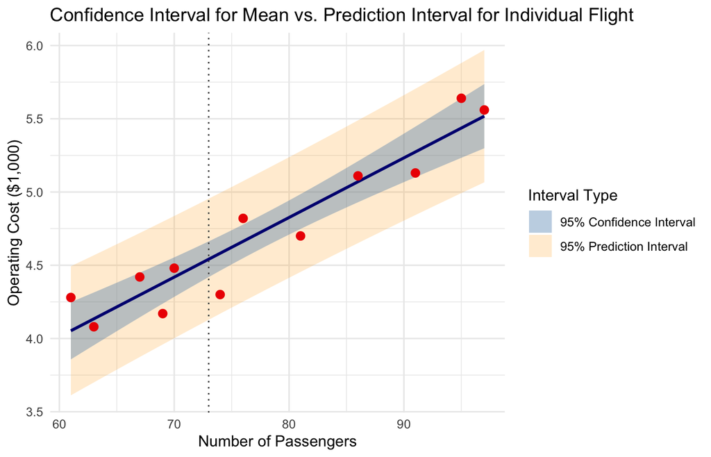

```r
grid_x <- data.frame(no_of_pass = seq(min(no_of_pass), max(no_of_pass), length.out = 100))
ci_band <- as.data.frame(predict(airline_model, newdata = grid_x, interval = "confidence"))
pi_band <- as.data.frame(predict(airline_model, newdata = grid_x, interval = "prediction"))
band_df <- data.frame(
  no_of_pass = grid_x$no_of_pass,
  fit = ci_band$fit,
  ci_lwr = ci_band$lwr,
  ci_upr = ci_band$upr,
  pi_lwr = pi_band$lwr,
  pi_upr = pi_band$upr
)

ggplot(band_df, aes(x = no_of_pass, y = fit)) +
  geom_ribbon(aes(ymin = pi_lwr, ymax = pi_upr, fill = "95% Prediction Interval"), alpha = 0.2) +
  geom_ribbon(aes(ymin = ci_lwr, ymax = ci_upr, fill = "95% Confidence Interval"), alpha = 0.35) +
  geom_line(color = "navy", linewidth = 1) +
  geom_point(data = airline_df, aes(x = no_of_pass, y = cost_1000), color = "red2", size = 2.5) +
  geom_vline(xintercept = 73, linetype = "dotted", color = "gray30") +
  scale_fill_manual(name = "Interval Type",
                    values = c("95% Confidence Interval" = "steelblue",
                               "95% Prediction Interval" = "orange")) +
  labs(title = "Confidence Interval for Mean vs. Prediction Interval for Individual Flight",
       x = "Number of Passengers",
       y = "Operating Cost ($1,000)") +
  theme_minimal()
```

## 2.4 Interpreting Regression Output, $r^2$, $F$-Test Equivalence & Trend-Line Forecasting (Sections 12.7 & 12.9)

- **Coefficient of Determination ($r^2$):**
  $$r^2 = \frac{SSR}{SST} = 1 -
  \frac{SSE}{SST}$$
  - **Inputs:** $SSR = \sum (\hat{y}_i - \bar{y})^2$ (regression sum of squares), $SSE = \sum (y_i - \hat{y}_i)^2$ (error sum of squares), and $SST = \sum (y_i - \bar{y})^2$ (total sum of squares).
- **Equivalence of Tests:** In simple linear regression, testing $H_0: \beta_1 = 0$ via the $t$-test is mathematically identical to the ANOVA regression $F$-test:
  $$F = \frac{MSR}{MSE} = \frac{SSR / 1}{SSE /
  (n - 2)} = t^2$$

```r
anova_airline <- anova(airline_model)
print(anova_airline)
```

```
## Analysis of Variance Table
##
## Response: cost_1000
##            Df  Sum Sq Mean Sq F value    Pr(>F)
## no_of_pass  1 2.79803 2.79803  89.092 2.692e-06 ***
## Residuals  10 0.31406 0.03141
## ---
## Signif. codes:  0 '***' 0.001 '**' 0.01 '*' 0.05 '.' 0.1 ' ' 1
```

```r
ssr_airline <- anova_airline["no_of_pass", "Sum Sq"]
sst_airline <- ssr_airline + sse_airline
r2_manual <- ssr_airline / sst_airline
f_manual <- (ssr_airline / 1) / (sse_airline / (n_airline - 2))
p_f_manual <- pf(f_manual, df1 = 1, df2 = n_airline - 2, lower.tail = FALSE)

print(sprintf("R^2 (formula) = %.6f | summary()$r.squared = %.6f",
              r2_manual, summary(airline_model)$r.squared))
```

```
## [1] "R^2 (formula) = 0.899084 | summary()$r.squared = 0.899084"
```

```r
print(sprintf("t^2 = %.4f | F_obs = %.4f | F p-value = %.6e",
              t_slope^2, f_manual, p_f_manual))
```

```
## [1] "t^2 = 89.0922 | F_obs = 89.0922 | F p-value = 2.691644e-06"
```

### 2.4.1 Trend-Line Forecasting (Section 12.9 — Demonstration Problem 12.7)

Simple linear regression can also model a linear time trend by encoding ordered time periods ($t = 1, 2, \dots, n$) as the independent variable. In **Demonstration Problem 12.7** (from the Chapter 12 R supplement), monthly sales from January ($t = 1$) through August ($t = 8$) are used to forecast sales for October ($t = 10$).

```r
month_fac <- factor(c("January", "February", "March", "April", "May", "June", "July", "August"),
                    levels = month.name)
month_num <- as.numeric(month_fac)
sales_trend <- c(32569, 32274, 32583, 32304, 32149, 32077, 31989, 31977)
trend_df <- data.frame(month_fac = month_fac, month_num = month_num, sales = sales_trend)

ts_regression <- lm(sales ~ month_num, data = trend_df)
oct_pred <- predict(ts_regression, newdata = data.frame(month_num = 10), interval = "prediction")

print(summary(ts_regression))
```

```
##
## Call:
## lm(formula = sales ~ month_num, data = trend_df)
##
## Residuals:
##      Min       1Q   Median       3Q      Max
## -181.786  -38.821   -6.643   29.875  213.429
##
## Coefficients:
##             Estimate Std. Error t value Pr(>|t|)
## (Intercept) 32628.21      93.28 349.805 3.68e-14 ***
## month_num     -86.21      18.47  -4.667  0.00344 **
## ---
## Signif. codes:  0 '***' 0.001 '**' 0.01 '*' 0.05 '.' 0.1 ' ' 1
##
## Residual standard error: 119.7 on 6 degrees of freedom
## Multiple R-squared:  0.7841, Adjusted R-squared:  0.7481
## F-statistic: 21.79 on 1 and 6 DF,  p-value: 0.00344
```

```r
print(sprintf("October (t = 10) Forecast: %.2f (95%% PI: [%.2f, %.2f])",
              oct_pred[1], oct_pred[2], oct_pred[3]))
```

```
## [1] "October (t = 10) Forecast: 31766.07 (95% PI: [31368.18, 32163.96])"
```

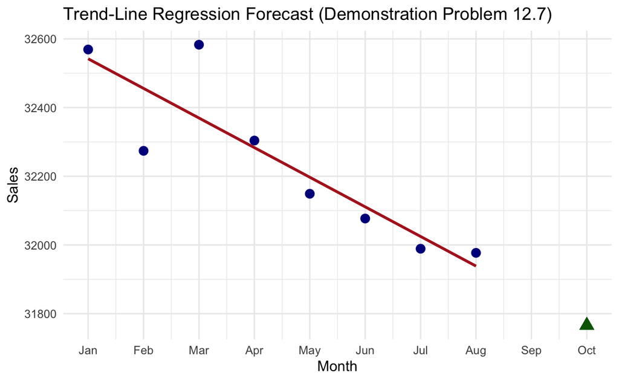

```r
ggplot(trend_df, aes(x = month_num, y = sales)) +
  geom_point(color = "darkblue", size = 2.8) +
  geom_smooth(method = "lm", se = FALSE, color = "firebrick") +
  scale_x_continuous(breaks = 1:10, labels = c(month.abb[1:8], "Sep", "Oct")) +
  geom_point(aes(x = 10, y = oct_pred[1]), color = "darkgreen", shape = 17, size = 3.5) +
  labs(title = "Trend-Line Regression Forecast (Demonstration Problem 12.7)",
       x = "Month",
       y = "Sales") +
  theme_minimal()
```

# 3 Wilcox Chapter 8 (Section 8.3): Deep Dive into Correlation & $r^2$

Rand Wilcox (*Basic Statistics*, Section 8.3) provides crucial mathematical connections and practical warnings regarding Pearson’s product-moment correlation ($r$) and the coefficient of determination ($r^2$).

## 3.1 Connecting Slope, Correlation, and $r^2$

- **Algebraic Link Between $r$ and Slope $b_1$:**
  $$r = b_1 \left(\frac{s_x}{s_y}\right) \quad
  \Longleftrightarrow \quad b_1 = r \left(\frac{s_y}{s_x}\right)$$
  - **Inputs:** $b_1$ (OLS slope), $s_x$ (sample SD of $X$), $s_y$ (sample SD of $Y$).
- **Three Equivalent Interpretations of $r^2$:**
  1. **Proportional Reduction in Error:** Comparing prediction error using the regression line ($\sum (Y_i - \hat{Y}_i)^2$) against predicting with the sample mean alone ($\sum (Y_i - \bar{Y})^2$):
     $$r^2 =
     \frac{\sum (Y_i - \bar{Y})^2 - \sum (Y_i - \hat{Y}_i)^2}{\sum (Y_i -
     \bar{Y})^2}$$
  2. **Complement of Unexplained Variance:** $r^2 = 1 - \frac{\text{Var}(e)}{\text{Var}(Y)}$.
  3. **Squared Correlation Between Observed and Predicted $Y$:** $r^2 = [\text{Cor}(Y, \hat{Y})]^2$.

```r
r_from_slope <- b1 * (sd(no_of_pass) / sd(cost_1000))
r_direct <- cor(no_of_pass, cost_1000)

r2_pre <- (sum((cost_1000 - mean(cost_1000))^2) - sum((cost_1000 - fitted(airline_model))^2)) /
  sum((cost_1000 - mean(cost_1000))^2)
r2_var <- 1 - var(residuals(airline_model)) / var(cost_1000)
r2_y_yhat <- cor(cost_1000, fitted(airline_model))^2

print(sprintf("r via b1*(sx/sy) = %.6f | cor(x, y) = %.6f", r_from_slope, r_direct))
```

```
## [1] "r via b1*(sx/sy) = 0.948200 | cor(x, y) = 0.948200"
```

```r
print(sprintf("r^2 (PRE) = %.6f | r^2 (1 - Var(e)/Var(Y)) = %.6f | Cor(Y, Y_hat)^2 = %.6f",
              r2_pre, r2_var, r2_y_yhat))
```

```
## [1] "r^2 (PRE) = 0.899084 | r^2 (1 - Var(e)/Var(Y)) = 0.899084 | Cor(Y, Y_hat)^2 = 0.899084"
```

## 3.2 Population Correlation ($\rho$), Independence, and Testing $H_0: \rho = 0$

- **Independence $\implies \rho = 0$:** If $X$ and $Y$ are statistically independent, then $\rho = 0$. Therefore, empirical evidence that $\rho \ne 0$ implies $X$ and $Y$ are dependent.
- **$\rho = 0 \not\implies$ Independence:** Having $\rho = 0$ does **not** prove independence.
  - *Curvature:* If $Y = X^2$ (symmetric around $0$), there is an exact deterministic relationship, yet $\rho = 0$.
  - *Heteroscedasticity with Zero Slope:* Even when the regression line is completely flat ($\beta_1 = 0, \rho = 0$), if the spread of $Y$ changes with $X$, knowing $X$ still provides information about $Y$.

### 3.2.1 Classic Student’s $t$-Test for $H_0: \rho = 0$

$$T = r \sqrt{\frac{n - 2}{1 - r^2}},
\quad \text{with } df = n - 2$$

- **Inputs:**
  - $r$: Sample Pearson correlation coefficient.
  - $n$: Number of paired observations.
  - Reject $H_0: \rho = 0$ if $|T| \ge t_{1 - \alpha/2,\, n-2}$.

### 3.2.2 R Application: Interest Rate & Futures Index (Black Table 12.1, Ch. 12 R Supplement)

```r
interest_rate <- c(7.43, 7.48, 8, 7.75, 7.6, 7.63, 7.68, 7.67, 7.59, 8.07, 8.03, 8)
futures <- c(221, 222, 226, 225, 224, 223, 223, 226, 226, 235, 233, 241)

n_fut <- length(interest_rate)
r_fut <- cor(interest_rate, futures)
T_fut <- r_fut * sqrt((n_fut - 2) / (1 - r_fut^2))
p_fut <- 2 * pt(abs(T_fut), df = n_fut - 2, lower.tail = FALSE)

print(sprintf("r = %.6f | Manual T = %.4f (df = %d) | p-value = %.6f",
              r_fut, T_fut, n_fut - 2, p_fut))
```

```
## [1] "r = 0.815254 | Manual T = 4.4518 (df = 10) | p-value = 0.001232"
```

```r
print(cor.test(interest_rate, futures, alternative = "two.sided", method = "pearson"))
```

```
##
##  Pearson's product-moment correlation
##
## data:  interest_rate and futures
## t = 4.4518, df = 10, p-value = 0.001232
## alternative hypothesis: true correlation is not equal to 0
## 95 percent confidence interval:
##  0.4535630 0.9463714
## sample estimates:
##       cor
## 0.8152537
```

### 3.2.3 Wilcox’s Critical Warning: Curvature & The Heteroscedasticity Trap

The derivation of Student’s $T$ relies heavily on **homoscedasticity**. When heteroscedasticity is present, $T$ uses the **wrong standard error**. Even when the true slope and correlation are zero ($\rho = 0$), the probability of falsely rejecting $H_0$ can inflate well above $\alpha = 0.05$. Thus, $T$ is more accurately viewed as a test of **independence** rather than strictly a test that $\rho = 0$.

```r
set.seed(401)
x_curve <- seq(-5, 5, length.out = 21)
y_curve <- x_curve^2
curve_test <- cor.test(x_curve, y_curve)
print(sprintf("Deterministic Y = X^2: r = %.4f | p-value = %.4f",
              curve_test$estimate, curve_test$p.value))
```

```
## [1] "Deterministic Y = X^2: r = -0.0000 | p-value = 1.0000"
```

```r
n_sim <- 1000
n_obs <- 100
reject_count <- 0
for (i in 1:n_sim) {
  x_het <- runif(n_obs, -3, 3)
  y_het <- (x_het^2) * rnorm(n_obs, mean = 0, sd = 1)
  if (cor.test(x_het, y_het)$p.value < 0.05) {
    reject_count <- reject_count + 1
  }
}
print(sprintf("Heteroscedastic rho = 0 simulation (alpha = 0.05): empirical rejection rate = %.3f",
              reject_count / n_sim))
```

```
## [1] "Heteroscedastic rho = 0 simulation (alpha = 0.05): empirical rejection rate = 0.178"
```

## 3.3 Five Data Features That Distort the Magnitude of $r$

Wilcox highlights five features that strongly influence $r$, warning against interpreting $r$ without plotting the data:

1. **Slope of the Line:** When residual spread is held constant, a flatter slope (closer to $0$) produces a smaller $|r|$.
2. **Magnitude of the Residuals:** Larger vertical scatter around the same regression line reduces $|r|$.
3. **Outliers:** A single extreme point can dramatically inflate $r$ or reverse its sign.
4. **Range Restriction:** Restricting the range of $X$ or $Y$ values can artificially raise or lower $r$.
5. **Curvature:** Non-linear relationships are poorly captured by $r$, which only measures straight-line association.

> **Wilcox’s Golden Rule:** *Always inspect a scatterplot with the fitted regression line overlaid. Even a high $r^2$ close to $1$ does not guarantee that $\hat{Y}$ provides practically accurate predictions if both $\hat{Y}$ and $\bar{Y}$ have large errors.*

```r
set.seed(99)
x_base <- seq(1, 10, length.out = 25)
y_tight <- 2 + 1.5 * x_base + rnorm(25, 0, 1.0)
y_noisy <- 2 + 1.5 * x_base + rnorm(25, 0, 5.5)

x_out <- c(x_base[1:24], 25)
y_out <- c(y_tight[1:24], -15)

idx_sub <- x_base >= 4 & x_base <= 7
x_rest <- x_base[idx_sub]
y_rest <- y_noisy[idx_sub]

r_tight <- cor(x_base, y_tight)
r_noisy <- cor(x_base, y_noisy)
r_out <- cor(x_out, y_out)
r_rest <- cor(x_rest, y_rest)

print(sprintf("r (Tight Linear) = %.3f | r (High Noise) = %.3f | r (Single Outlier) = %.3f | r (Restricted Range) = %.3f",
              r_tight, r_noisy, r_out, r_rest))
```

```
## [1] "r (Tight Linear) = 0.970 | r (High Noise) = 0.437 | r (Single Outlier) = -0.317 | r (Restricted Range) = 0.425"
```

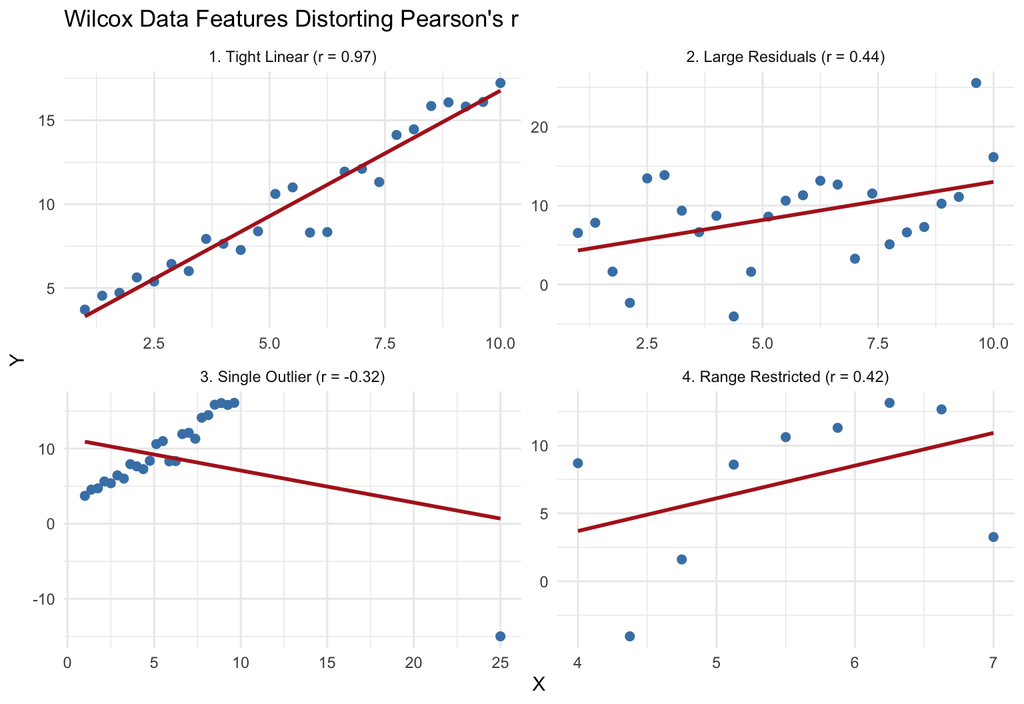

```r
feat_df <- rbind(
  data.frame(x = x_base, y = y_tight, scenario = sprintf("1. Tight Linear (r = %.2f)", r_tight)),
  data.frame(x = x_base, y = y_noisy, scenario = sprintf("2. Large Residuals (r = %.2f)", r_noisy)),
  data.frame(x = x_out,  y = y_out,   scenario = sprintf("3. Single Outlier (r = %.2f)", r_out)),
  data.frame(x = x_rest, y = y_rest,  scenario = sprintf("4. Range Restricted (r = %.2f)", r_rest))
)

ggplot(feat_df, aes(x = x, y = y)) +
  geom_point(color = "steelblue", size = 2) +
  geom_smooth(method = "lm", se = FALSE, color = "firebrick") +
  facet_wrap(~ scenario, scales = "free") +
  labs(title = "Wilcox Data Features Distorting Pearson's r",
       x = "X",
       y = "Y") +
  theme_minimal()
```

# 4 Black Chapter 13: Multiple Regression Analysis

Multiple regression extends simple linear regression by modeling a dependent variable $Y$ as a linear function of **$k$ independent predictor variables** ($X_1, X_2, \dots, X_k$).

## 4.1 The Multiple Regression Model (Section 13.1)

- **Population Model:**
  $$Y_i
  = \beta_0 + \beta_1 X_{1i} + \beta_2 X_{2i} + \dots + \beta_k X_{ki} +
  \epsilon_i$$
- **Estimated Sample Equation:**
  $$\hat{y}_i = b_0 + b_1 x_{1i} + b_2 x_{2i} + \dots
  + b_k x_{ki}$$
- **Inputs & Interpretation:**
  - $b_0$: Sample $y$-intercept (predicted $Y$ when all $x_j = 0$).
  - $b_j$ (**Partial Regression Coefficients**): Expected change in $\hat{y}$ for a $1$-unit increase in $x_j$, **holding all other independent variables constant** (*ceteris paribus*).

### 4.1.1 R Application: Demonstration Problem 13.1 — Prime Interest Rate (Black p. 479, Ch. 13 R Supplement)

Using 15 even-numbered years over a 28-year span, we model the annual U.S. prime interest rate (`interest`) as a linear function of the annual unemployment rate (`unemployment`) and annual personal saving rate (`savings`), and predict the prime interest rate when `unemployment = 6.5` and `savings = 5.0`.

```r
interest_rate <- c(8.33, 9.32, 10.01, 6.25, 7.15, 8.27, 8.35, 9.23, 4.67, 4.34,
                   7.96, 5.09, 3.25, 3.25, 3.25)
unemp_rate <- c(7, 5.5, 5.6, 7.5, 6.1, 5.4, 4.5, 4, 5.8, 5.5, 4.6, 5.8, 9.6, 8.1, 6.2)
pers_saving <- c(8.2, 7.3, 7, 7.7, 4.8, 4, 4.3, 2.3, 2.4, 2.1, 0.7, 1.8, 5.8, 7.6, 4.8)

demo_13.1 <- data.frame(interest = interest_rate,
                        unemployment = unemp_rate,
                        savings = pers_saving)

prime_model <- lm(interest ~ unemployment + savings, data = demo_13.1)
print(summary(prime_model))
```

```
##
## Call:
## lm(formula = interest ~ unemployment + savings, data = demo_13.1)
##
## Residuals:
##     Min      1Q  Median      3Q     Max
## -3.1846 -0.7148  0.0754  1.0092  1.8082
##
## Coefficients:
##              Estimate Std. Error t value Pr(>|t|)
## (Intercept)   13.5786     1.7276   7.860  4.5e-06 ***
## unemployment  -1.6622     0.3372  -4.929 0.000349 ***
## savings        0.6586     0.1990   3.309 0.006234 **
## ---
## Signif. codes:  0 '***' 0.001 '**' 0.01 '*' 0.05 '.' 0.1 ' ' 1
##
## Residual standard error: 1.496 on 12 degrees of freedom
## Multiple R-squared:  0.6719, Adjusted R-squared:  0.6172
## F-statistic: 12.29 on 2 and 12 DF,  p-value: 0.001248
```

```r
prime_pred <- predict(prime_model,
                      newdata = data.frame(unemployment = 6.5, savings = 5.0),
                      interval = "confidence")
print(sprintf("Predicted Prime Interest Rate (unemp = 6.5, savings = 5.0): %.4f%% (95%% CI: [%.4f%%, %.4f%%])",
              prime_pred[1], prime_pred[2], prime_pred[3]))
```

```
## [1] "Predicted Prime Interest Rate (unemp = 6.5, savings = 5.0): 6.0676% (95% CI: [5.1876%, 6.9476%])"
```

## 4.2 Evaluating the Multiple Regression Model (Sections 13.2–13.3)

### 4.2.1 Overall Significance: The Global $F$-Test

Tests whether *at least one* predictor variable contributes significantly to explaining $Y$:

- $H_0: \beta_1 = \beta_2 = \dots = \beta_k = 0$
- $H_a: \text{At least one } \beta_j \ne 0$
- **Test Statistic:**
  $$F =
  \frac{MSR}{MSE} = \frac{SSR / k}{SSE / (n - k - 1)}, \quad \text{with }
  df_1 = k, \; df_2 = n - k - 1$$
- **Inputs:** $SSR$ (regression sum of squares), $SSE$ (error sum of squares), $k$ (number of predictors), and $n$ (sample size).

### 4.2.2 Individual Predictor Significance: Partial $t$-Tests

Tests whether a specific predictor $X_j$ is significant after accounting for all other predictors in the model:

- $H_0: \beta_j = 0$ vs. $H_a: \beta_j \ne 0$
- **Test Statistic:**
  $$t =
  \frac{b_j - 0}{s_{b_j}}, \quad \text{with } df = n - k - 1$$
- **Inputs:** $b_j$ (partial slope estimate) and $s_{b_j}$ (standard error of $b_j$).

### 4.2.3 Multiple $R^2$, Adjusted $R^2$, and Standard Error ($s_e$)

- **Standard Error of the Estimate:**
  $$s_e = \sqrt{\frac{SSE}{n - k - 1}}$$
- **Multiple Coefficient of Determination ($R^2$):**
  $$R^2 = \frac{SSR}{SST} = 1 -
  \frac{SSE}{SST}$$
  *(Adding any predictor—even pure noise—never decreases $R^2$).*
- **Adjusted $R^2$ ($R_{\text{adj}}^2$):** Penalizes model complexity by adjusting for degrees of freedom:
  $$R_{\text{adj}}^2 = 1 - \left[ (1 - R^2) \frac{n -
  1}{n - k - 1} \right]$$
  Use **$R_{\text{adj}}^2$** (not raw $R^2$) when comparing competing multiple regression models with different numbers of predictors.

```r
n_p <- nrow(demo_13.1)
k_p <- 2
sse_p <- sum(residuals(prime_model)^2)
sst_p <- sum((demo_13.1$interest - mean(demo_13.1$interest))^2)
ssr_p <- sst_p - sse_p

se_p <- sqrt(sse_p / (n_p - k_p - 1))
r2_p <- ssr_p / sst_p
adj_r2_p <- 1 - ((1 - r2_p) * (n_p - 1) / (n_p - k_p - 1))
f_p <- (ssr_p / k_p) / (sse_p / (n_p - k_p - 1))
p_f_p <- pf(f_p, df1 = k_p, df2 = n_p - k_p - 1, lower.tail = FALSE)

print(sprintf("s_e = %.4f | R^2 = %.4f | Adjusted R^2 = %.4f", se_p, r2_p, adj_r2_p))
```

```
## [1] "s_e = 1.4959 | R^2 = 0.6719 | Adjusted R^2 = 0.6172"
```

```r
print(sprintf("Global F(%d, %d) = %.4f | p-value = %.6f", k_p, n_p - k_p - 1, f_p, p_f_p))
```

```
## [1] "Global F(2, 12) = 12.2851 | p-value = 0.001248"
```

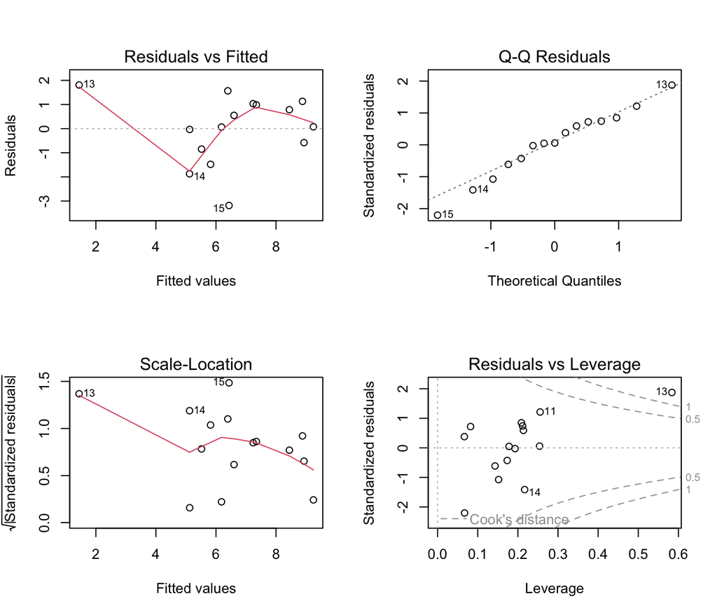

```r
par(mfrow = c(2, 2))
plot(prime_model)
```

## 4.3 Dummy Variables, Iterative Modeling & Multicollinearity (Sections 13.4–13.5)

### 4.3.1 Qualitative (Dummy / Indicator) Variables

Categorical predictors with $c$ levels are encoded using **$c - 1$ binary ($0/1$) dummy variables** to avoid perfect collinearity (the “dummy variable trap”). The omitted category serves as the **reference (baseline) group**.

### 4.3.2 R Application: Tableware Pricing — Dummy Indicators, Covariate Addition & Log Transformation

Using [`tableware.csv`](https://raw.githubusercontent.com/telpirion/CumulativeStudyGuide/refs/heads/main/data/tableware.csv) from the Lesson 12 solutions, we compare: 1. **Binary indicator model (`PRICE ~ BOWL + CASS + DISH + TRAY`):** Here `plate` has $0$ across all four indicators and serves as the reference category ($\hat{y}_{\text{plate}} = b_0 = 51.83$), while each coefficient measures the incremental price difference relative to a plate. 2. **Factor contrast model (`PRICE ~ TYPE`):** R automatically creates $c - 1$ treatment contrasts using the alphabetically first level (`bowl`) as the baseline ($b_0 = 67.39$). 3. **Adding a quantitative covariate (`PRICE ~ DIAM + TYPE`):** Including diameter (`DIAM`) increases $R_{\text{adj}}^2$ from $0.2876$ to $0.7204$, though residual diagnostics show increasing error variance (heteroscedasticity). 4. **Logarithmic transformation (`log10(PRICE) ~ log10(DIAM) + TYPE`):** Stabilizes variance ($R_{\text{adj}}^2 = 0.8187$), confirmed by Bartlett’s test for homogeneity of variances ($p = 0.8267$) and cross-checked with robust regression (`MASS::rlm()`).

```r
tableware <- read.csv("https://raw.githubusercontent.com/telpirion/CumulativeStudyGuide/refs/heads/main/data/tableware.csv")
tableware$TYPE <- factor(tableware$TYPE)

m_dummy <- lm(PRICE ~ BOWL + CASS + DISH + TRAY, data = tableware)
m_factor <- lm(PRICE ~ TYPE, data = tableware)
m_cov <- lm(PRICE ~ DIAM + TYPE, data = tableware)
m_log <- lm(log10(PRICE) ~ log10(DIAM) + TYPE, data = tableware)

print(summary(m_dummy))
```

```
##
## Call:
## lm(formula = PRICE ~ BOWL + CASS + DISH + TRAY, data = tableware)
##
## Residuals:
##     Min      1Q  Median      3Q     Max
## -76.950 -26.362  -2.333  26.109  90.050
##
## Coefficients:
##             Estimate Std. Error t value Pr(>|t|)
## (Intercept)    51.83      12.11   4.281 7.68e-05 ***
## BOWL           15.56      14.28   1.089  0.28086
## CASS           75.09      16.69   4.499 3.67e-05 ***
## DISH           28.31      18.31   1.546  0.12785
## TRAY           47.12      16.69   2.823  0.00665 **
## ---
## Signif. codes:  0 '***' 0.001 '**' 0.01 '*' 0.05 '.' 0.1 ' ' 1
##
## Residual standard error: 36.33 on 54 degrees of freedom
## Multiple R-squared:  0.3367, Adjusted R-squared:  0.2876
## F-statistic: 6.853 on 4 and 54 DF,  p-value: 0.0001548
```

```r
print(sprintf("Mean PRICE for plates (reference group): %.2f",
              mean(tableware$PRICE[tableware$TYPE == "plate"])))
```

```
## [1] "Mean PRICE for plates (reference group): 51.83"
```

```r
print(sprintf("Adj R^2 comparison -> TYPE only: %.4f | DIAM + TYPE: %.4f | log10 model: %.4f",
              summary(m_factor)$adj.r.squared,
              summary(m_cov)$adj.r.squared,
              summary(m_log)$adj.r.squared))
```

```
## [1] "Adj R^2 comparison -> TYPE only: 0.2876 | DIAM + TYPE: 0.7204 | log10 model: 0.8187"
```

```r
class_intervals <- cut(fitted(m_log), breaks = 5)
bartlett_res <- bartlett.test(residuals(m_log) ~ class_intervals)
print(bartlett_res)
```

```
##
##  Bartlett test of homogeneity of variances
##
## data:  residuals(m_log) by class_intervals
## Bartlett's K-squared = 1.4999, df = 4, p-value = 0.8267
```

```r
m_robust <- rlm(log10(PRICE) ~ log10(DIAM) + TYPE, data = tableware)
coef_compare <- cbind(OLS_log10 = round(coef(m_log), 3),
                      Robust_rlm = round(coef(m_robust), 3))
print(coef_compare)
```

```
##             OLS_log10 Robust_rlm
## (Intercept)     0.458      0.471
## log10(DIAM)     1.389      1.369
## TYPEcass        0.116      0.140
## TYPEdish        0.092      0.089
## TYPEplate      -0.182     -0.174
## TYPEtray       -0.080     -0.061
```

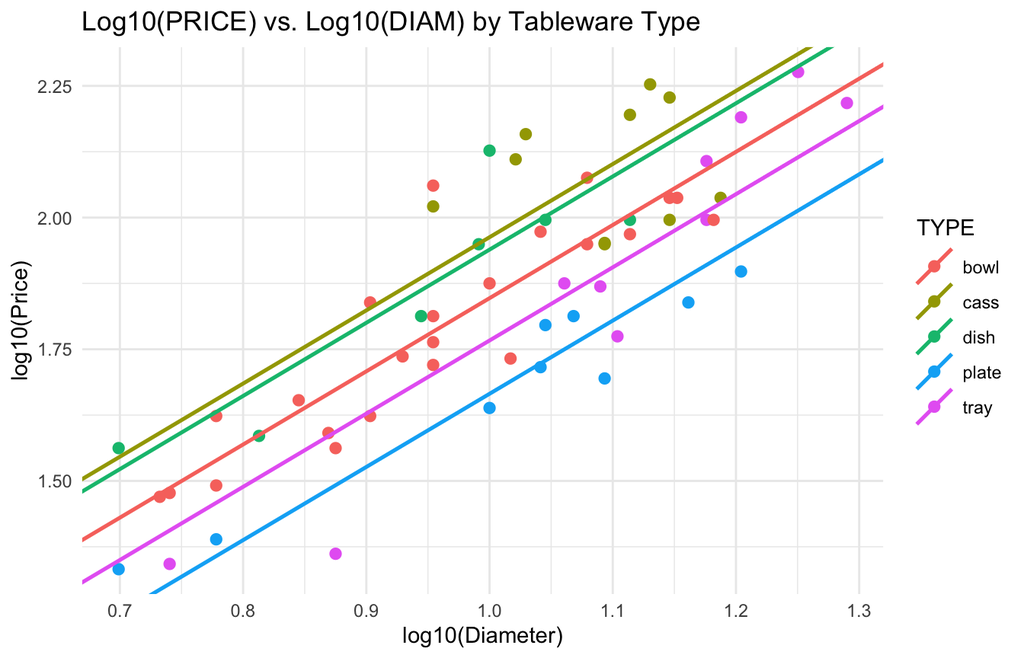

```r
b_int <- coef(m_log)[1]
type_levels <- levels(tableware$TYPE)
line_df <- data.frame(
  TYPE = type_levels,
  intercept = c(b_int,
                b_int + coef(m_log)["TYPEcass"],
                b_int + coef(m_log)["TYPEdish"],
                b_int + coef(m_log)["TYPEplate"],
                b_int + coef(m_log)["TYPEtray"]),
  slope = coef(m_log)["log10(DIAM)"]
)

ggplot(tableware, aes(x = log10(DIAM), y = log10(PRICE), color = TYPE)) +
  geom_point(size = 2.2) +
  geom_abline(data = line_df, aes(intercept = intercept, slope = slope, color = TYPE), linewidth = 0.9) +
  labs(title = "Log10(PRICE) vs. Log10(DIAM) by Tableware Type",
       x = "log10(Diameter)",
       y = "log10(Price)") +
  theme_minimal()
```

### 4.3.3 Multicollinearity & Variance Inflation Factor ($VIF$)

**Multicollinearity** occurs when two or more independent predictors ($X_j$ and $X_m$) are highly correlated with each other.

- **Consequences:** Does not bias predictions ($\hat{y}$) or $R^2$, but dramatically inflates standard errors ($s_{b_j}$), causing partial $t$-statistics to shrink (predictors appear insignificant despite a highly significant overall $F$-test) and causing coefficient signs to flip erratically.
- **Detection via $VIF$:** For each predictor $X_j$, regress $X_j$ on all remaining predictors to obtain $R_j^2$:
  $$VIF_j = \frac{1}{1 - R_j^2}$$
  - **Inputs:** $R_j^2$, the coefficient of determination from regressing $X_j$ onto all other predictors.
  - $VIF_j = 1$: No correlation with other predictors.
  - $VIF_j > 5$ (or $> 10$ in Black): Indicates problematic multicollinearity requiring variable removal or combination.

```r
r2_unemp <- summary(lm(unemployment ~ savings, data = demo_13.1))$r.squared
r2_sav <- summary(lm(savings ~ unemployment, data = demo_13.1))$r.squared
vif_prime <- 1 / (1 - c(unemployment = r2_unemp, savings = r2_sav))
print(sprintf("Demo 13.1 VIF -> unemployment: %.3f | savings: %.3f",
              vif_prime["unemployment"], vif_prime["savings"]))
```

```
## [1] "Demo 13.1 VIF -> unemployment: 1.519 | savings: 1.519"
```

```r
set.seed(42)
n_sim_vif <- 40
ad_spend <- runif(n_sim_vif, 5, 25)
ad_clicks <- 10 * ad_spend + rnorm(n_sim_vif, 0, 4)
store_size <- runif(n_sim_vif, 5, 20)
sales_vif <- 15 + 2.2 * ad_spend + 1.0 * store_size + rnorm(n_sim_vif, 0, 3)
collinear_df <- data.frame(sales = sales_vif, ad_spend = ad_spend,
                           ad_clicks = ad_clicks, store_size = store_size)

m_collinear <- lm(sales ~ ad_spend + ad_clicks + store_size, data = collinear_df)
print(summary(m_collinear))
```

```
##
## Call:
## lm(formula = sales ~ ad_spend + ad_clicks + store_size, data = collinear_df)
##
## Residuals:
##     Min      1Q  Median      3Q     Max
## -4.8119 -1.8260 -0.1419  1.6719  7.3806
##
## Coefficients:
##             Estimate Std. Error t value Pr(>|t|)
## (Intercept) 15.99878    2.01359   7.945 1.97e-09 ***
## ad_spend     1.89354    1.14398   1.655    0.107
## ad_clicks    0.03317    0.11368   0.292    0.772
## store_size   0.90502    0.11374   7.957 1.90e-09 ***
## ---
## Signif. codes:  0 '***' 0.001 '**' 0.01 '*' 0.05 '.' 0.1 ' ' 1
##
## Residual standard error: 2.989 on 36 degrees of freedom
## Multiple R-squared:  0.9614, Adjusted R-squared:  0.9581
## F-statistic: 298.5 on 3 and 36 DF,  p-value: < 2.2e-16
```

```r
r2_spend <- summary(lm(ad_spend ~ ad_clicks + store_size, data = collinear_df))$r.squared
r2_clicks <- summary(lm(ad_clicks ~ ad_spend + store_size, data = collinear_df))$r.squared
r2_size <- summary(lm(store_size ~ ad_spend + ad_clicks, data = collinear_df))$r.squared
vif_collinear <- 1 / (1 - c(ad_spend = r2_spend, ad_clicks = r2_clicks, store_size = r2_size))
print(round(vif_collinear, 2))
```

```
##   ad_spend  ad_clicks store_size
##     211.13     211.38       1.02
```

Notice that in the collinear model, the overall $F$-test is overwhelmingly significant ($p < 10^{-10}$, $R^2 > 0.90$), yet both `ad_spend` and `ad_clicks` have inflated standard errors and high $VIF$ values ($VIF > 10$), masking their individual $t$-test significance.

# 5 Week 9 Key Formula Summary Sheet

| Concept / Metric | Formula | Degrees of Freedom / R Implementation |
| --- | --- | --- |
| **Residual & $s_e$ (SLR)** | $e_i = y_i - \hat{y}_i, \quad s_e = \sqrt{\dfrac{SSE}{n - 2}}$ | $df = n - 2$; `residuals(m)`, `summary(m)$sigma` |
| **Slope $t$-Test (SLR)** | $t = \dfrac{b_1 - \beta_{1,0}}{s_{b_1}}$, where $s_{b_1} = \dfrac{s_e}{\sqrt{SS_{xx}}}$ | $df = n - 2$; `coef(summary(m))`, `confint(m)` |
| **Correlation $t$-Test (Wilcox)** | $T = r \sqrt{\dfrac{n - 2}{1 - r^2}}$ | $df = n - 2$; `cor.test(x, y)`; sensitive to heteroscedasticity |
| **CI for Conditional Mean** | $\hat{y}_0 \pm t_{\alpha/2,\, n-2} \, s_e \sqrt{\dfrac{1}{n} + \dfrac{(x_0 - \bar{x})^2}{SS_{xx}}}$ | `predict(m, newdata, interval = "confidence")` |
| **PI for Individual $Y_0$** | $\hat{y}_0 \pm t_{\alpha/2,\, n-2} \, s_e \sqrt{1 + \dfrac{1}{n} + \dfrac{(x_0 - \bar{x})^2}{SS_{xx}}}$ | `predict(m, newdata, interval = "prediction")` |
| **Multiple Regression $F$-Test** | $F = \dfrac{MSR}{MSE} = \dfrac{SSR / k}{SSE / (n - k - 1)}$ | $df_1 = k$, $df_2 = n - k - 1$; `summary(m)$fstatistic` |
| **Partial $t$-Test & $s_e$ (MLR)** | $t = \dfrac{b_j}{s_{b_j}}, \quad s_e = \sqrt{\dfrac{SSE}{n - k - 1}}$ | $df = n - k - 1$; `summary(m)$coefficients` |
| **Adjusted $R^2$** | $R_{\text{adj}}^2 = 1 - \left[(1 - R^2)\dfrac{n - 1}{n - k - 1}\right]$ | `summary(m)$adj.r.squared`; penalizes extra predictors |
| **Variance Inflation Factor** | $VIF_j = \dfrac{1}{1 - R_j^2}$ | $VIF > 5$ or $10$ signals multicollinearity |

## Navigation & Practice

- **Practice & Exercises:** [Week 9 Practice & Exercises (Jupyter Notebook)](https://colab.research.google.com/github/telpirion/CumulativeStudyGuide/blob/main/Week9.ipynb)